# HSC Survey Results

# Scots Bay Survey # 7 Results from 28/07/2025

## Survey Details

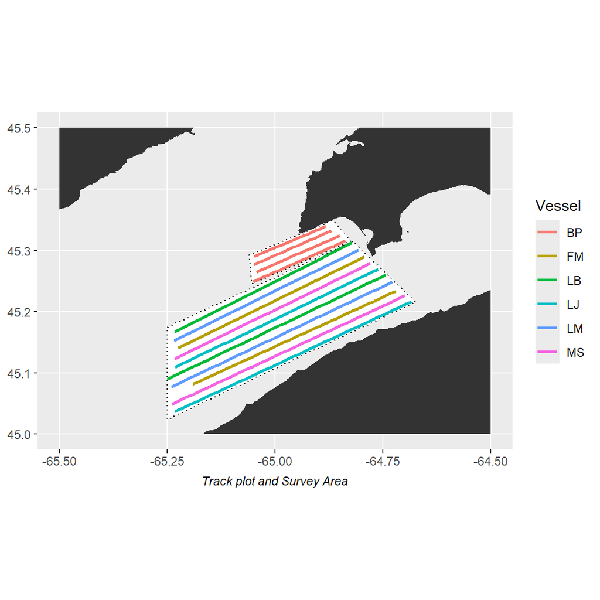

6 commercial purse seiners conducted this fishing survey on 28/07/2025 starting at 22:00:00, which was 6.5 hours after hide tide.

There was no plankton tow or CTD cast conducted.

No tags were applied during this survey.

Samples were obtained for target strength estimation.

### Tides Tables

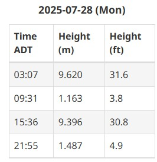

[figure not shown]

Tide Schedule for Margaretsville NS, Station #315m Source: www.waterlevels.gc.ca

### Acoustic Equipment

Each vessel was equipped with a Simrad ES38-18/200-18C combi (2-in-1) transducer prior to the survey that contains a 38kHz split beam and 200 kHz single beam transducer. Data was logged to the computer hard-drive for post-processing. All participating boats were calibrated on 38kHz before the survey.

## Survey Results

### Main Results

The results are subject to change as DFO will re-evaluate data editing, area estimation and apply a target strength.

**Preliminary biomass prediction for Scots Bay using standardized parallel transects is 7,573mt, and with turnover applied 6,612mt.**

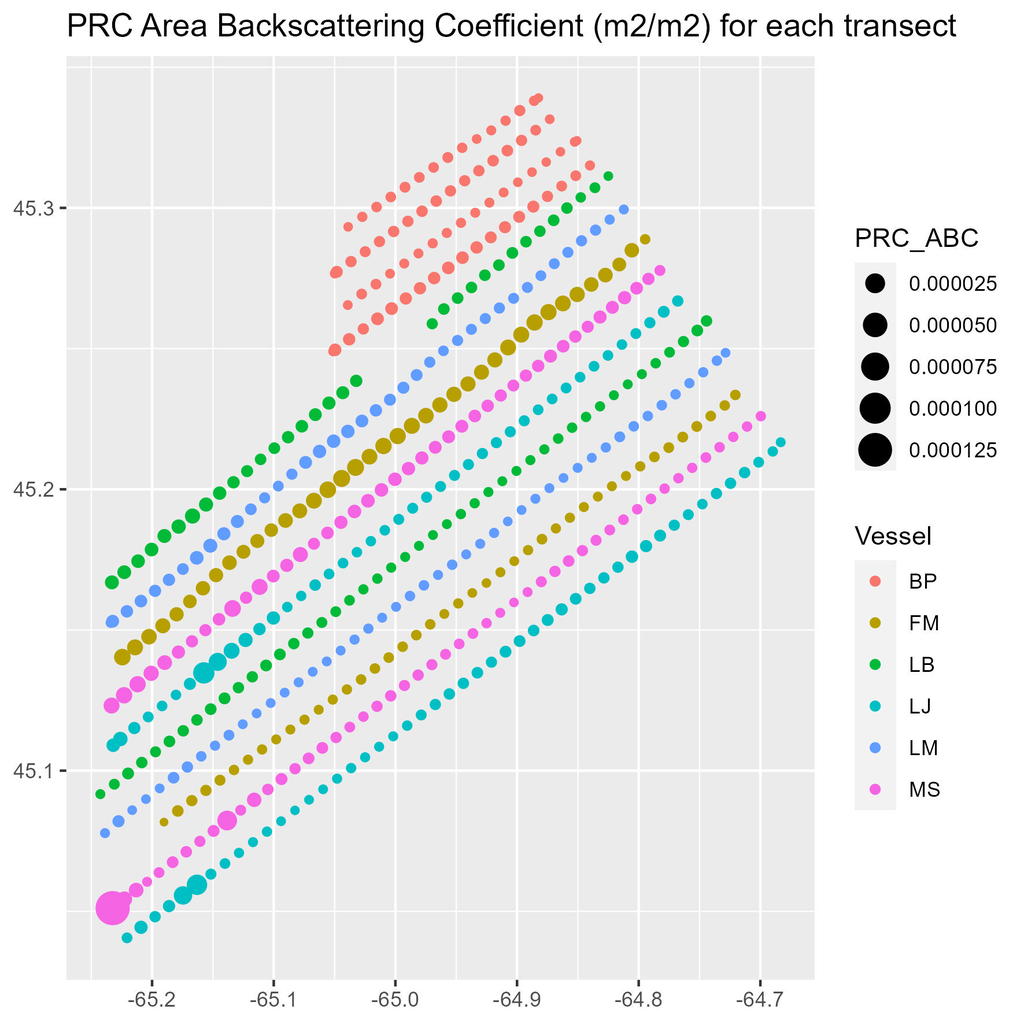

### Transect Details

Table 1: Transect Details

| Vessel | Transect # | Date/Time Start | Date/Time End | X | Y | Xend | Yend | Start Lat | Start Lon | End Lat | End Lon | Location | Distance (km) | Speed |
| --- | --- | --- | --- | --- | --- | --- | --- | --- | --- | --- | --- | --- | --- | --- |
| BP | T04 | 2025-07-29 00:00:19 | 2025-07-29 01:15:12 | -64.83736 | 45.31535 | -65.05125 | 45.24897 | NA | NA | NA | NA | SB | 18.37 | 7.95 |
| BP | T03 | 2025-07-28 23:00:51 | 2025-07-28 23:55:51 | -65.04345 | 45.26485 | -64.85082 | 45.32390 | NA | NA | NA | NA | SB | 16.50 | 9.72 |
| BP | T02 | 2025-07-28 22:01:11 | 2025-07-28 22:55:54 | -64.86966 | 45.33209 | -65.04978 | 45.27669 | NA | NA | NA | NA | SB | 15.43 | 9.14 |
| BP | T01 | 2025-07-28 21:06:21 | 2025-07-28 21:56:57 | -65.04808 | 45.29058 | -64.88236 | 45.33910 | NA | NA | NA | NA | SB | 14.10 | 9.03 |
| FM | T01 | 2025-07-28 22:56:29 | 2025-07-29 01:26:23 | -65.19044 | 45.08163 | -64.72057 | 45.23353 | NA | NA | NA | NA | SB | 40.84 | 8.83 |
| FM | T02 | 2025-07-29 02:13:12 | 2025-07-29 04:39:43 | -64.79320 | 45.28914 | -65.22445 | 45.14036 | NA | NA | NA | NA | SB | 38.03 | 8.41 |
| LB | T01 | 2025-07-28 20:56:18 | 2025-07-28 23:45:15 | -65.25009 | 45.08968 | -64.74423 | 45.25984 | NA | NA | NA | NA | SB | 44.37 | 8.51 |
| LB | T02 | 2025-07-29 00:44:11 | 2025-07-29 03:26:13 | -64.82212 | 45.31203 | -65.23303 | 45.16693 | NA | NA | NA | NA | SB | 37.16 | 7.43 |
| LJ | T01 | 2025-07-28 21:38:54 | 2025-07-29 00:33:02 | -65.23186 | 45.03679 | -64.68327 | 45.21672 | NA | NA | NA | NA | SB | 47.65 | 8.87 |
| LJ | T02 | 2025-07-29 01:12:43 | 2025-07-29 04:03:39 | -64.76068 | 45.26944 | -65.23194 | 45.10904 | NA | NA | NA | NA | SB | 41.16 | 7.80 |
| LM | T01 | 2025-07-28 22:03:08 | 2025-07-29 00:50:01 | -65.24063 | 45.07706 | -64.72862 | 45.24850 | NA | NA | NA | NA | SB | 44.82 | 8.70 |
| LM | T02 | 2025-07-29 01:34:37 | 2025-07-29 03:56:33 | -64.80702 | 45.30078 | -65.23402 | 45.15257 | NA | NA | NA | NA | SB | 37.59 | 8.58 |
| MS | T01 | 2025-07-28 20:51:36 | 2025-07-28 23:58:22 | -65.23903 | 45.04896 | -64.69908 | 45.22615 | NA | NA | NA | NA | SB | 48.72 | 8.45 |
| MS | T02 | 2025-07-29 00:54:46 | 2025-07-29 04:01:57 | -64.77868 | 45.27886 | -65.23330 | 45.12314 | NA | NA | NA | NA | SB | 42.37 | 7.33 |

### Survey Summary

Table 2: Acoustic Survey Results

| Vessel | Transect No. | Target Strength (db/kg) | Mean Sa (/m2) | Biomass Density (kg/m2) |
| --- | --- | --- | --- | --- |
| FM | T02 | -35.5 | -50.439 | 0.032 |
| MS | T02 | -35.5 | -53.317 | 0.017 |
| MS | T01 | -35.5 | -53.347 | 0.016 |
| LB | T02 | -35.5 | -55.225 | 0.011 |
| LJ | T02 | -35.5 | -55.457 | 0.010 |
| BP | T04 | -35.5 | -55.983 | 0.009 |
| LM | T02 | -35.5 | -56.202 | 0.009 |
| LJ | T01 | -35.5 | -56.245 | 0.008 |
| BP | T02 | -35.5 | -57.968 | 0.006 |
| LB | T01 | -35.5 | -59.583 | 0.004 |
| BP | T01 | -35.5 | -61.157 | 0.003 |
| FM | T01 | -35.5 | -61.303 | 0.003 |
| LM | T01 | -35.5 | -61.895 | 0.002 |
| BP | T03 | -35.5 | -63.073 | 0.002 |

Note:  
Transects are listed from greatest to least backscatter.

Table 3: Survey Summary Table

| Layer | Target Strength | Area (km2) | Mean Sa | Density (kg/m2) | Biomass (tons) | Percent Area | Percent Biomass | Standard Error (tons) | Standard Error (%) |
| --- | --- | --- | --- | --- | --- | --- | --- | --- | --- |
| Main Box | -35.5 | 651 | -55.4257 | 0.0093 | 7,573 | 76.2 | NA | 1,416.58 | 21.39 |
| Northern Box | NA | 87 | NA | NA | NA | 10.2 | NA | NA | NA |
| Eastern Box | NA | 116 | NA | NA | NA | 13.6 | NA | NA | NA |

### Greatest Biomass Densities

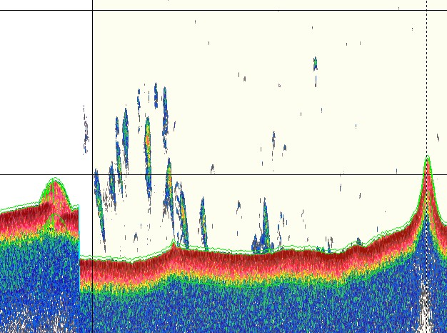

A snip from the transect with the greatest biomass density (kg/m2)

The single point with the largest biomass density (kg/m2) was recorded by **MS**, at the following location:

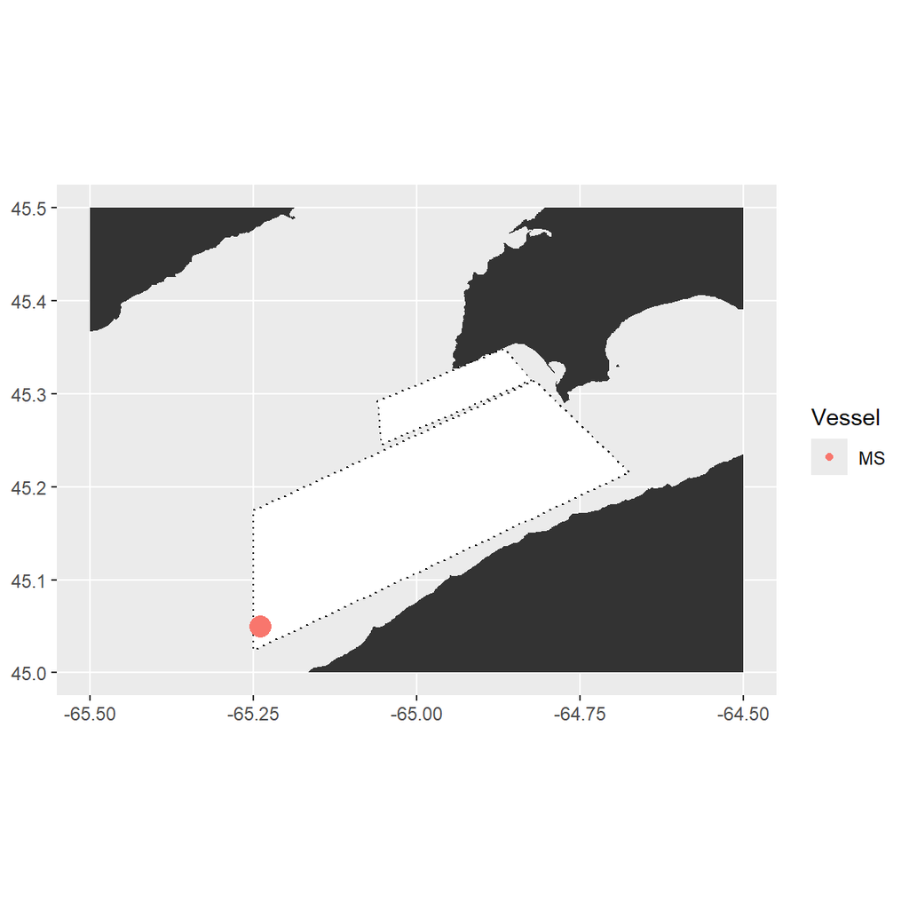

The transect with the greatest average biomass density (kg/m2) was recorded by **FM**, at the following location:

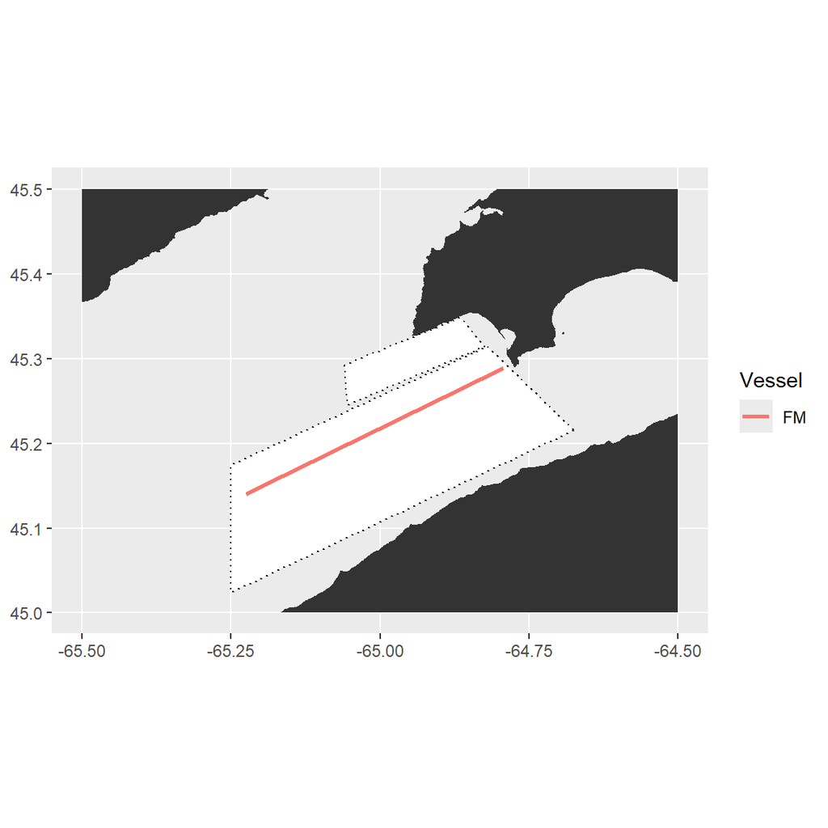

### Annual Summaries

This table does not include the biomass from adhoc surveys.

Table 4: Annual Comparison Table

| Ground | Survey Number | Current Year Survey Date | Current Year HSC Estimate | Current Year HSC Turnover Adjusted | Previous Year Survey Date | Previous Year HSC Estimate | Previous Year HSC Turnover Adjusted | Previous Year DFO Estimate | Previous Year DFO Turnover Adjusted |
| --- | --- | --- | --- | --- | --- | --- | --- | --- | --- |
| Scots Bay | 1 | 2025-05-06 | 12,306 | 12,306 | 2024-05-05 | 78,662 | 78,662 | 67,094 | 67,094 |
| Scots Bay | 2 | 2025-05-21 | 120,045 | 118,023 | 2024-05-20 | 29,842 | 17,255 | 28,750 | 20,566 |
| Scots Bay | 3 | 2025-06-03 | 123,037 | 109,821 | 2024-06-02 | 93,804 | 89,523 | 61,745 | 57,220 |
| Scots Bay | 4 | 2025-06-16 | 14,184 | 0 | 2024-06-16 | 33,347 | 22,278 | 32,605 | 23,965 |
| Scots Bay | 5 | 2025-06-30 | 15,789 | 11,509 | 2024-07-01 | 7,252 | 3,123 | 4,682 | 705 |
| Scots Bay | 6 | 2025-07-14 | 7,114 | 5,137 | 2024-07-15 | 4,539 | 3,560 | 4,816 | 4,183 |
| Scots Bay | 7 | 2025-07-28 | 7,573 | 6,612 | 2024-07-29 | 32,655 | 32,016 | 33,994 | 33,327 |
| Scots Bay | 8 | NA | NA | NA | 2024-08-11 | 15,213 | 10,296 | 13,079 | 7,959 |
| Scots Bay | 9 | NA | NA | NA | 2024-08-25 | 9,206 | 6,810 | 8,459 | 6,338 |
| Scots Bay | 10 | NA | NA | NA | 2024-09-08 | 13,418 | 12,121 | 8,621 | 7,432 |
| Scots Bay | 11 | NA | NA | NA | 2024-09-23 | 8,735 | 7,098 | 6,478 | 5,427 |

Table 5: Annual Summary Table

| Year | Ground | HSC Estimate | HSC Turnover Adjusted | DFO Estimate | DFO Turnover Adjusted |
| --- | --- | --- | --- | --- | --- |
| 2024 | Scots Bay | 326,673 | 282,742 | 270,323 | 234,216 |
| 2025 | Scots Bay | 300,048 | 263,408 | NA | NA |

## Tagging, Plankton, and CTD Data

### Summary map

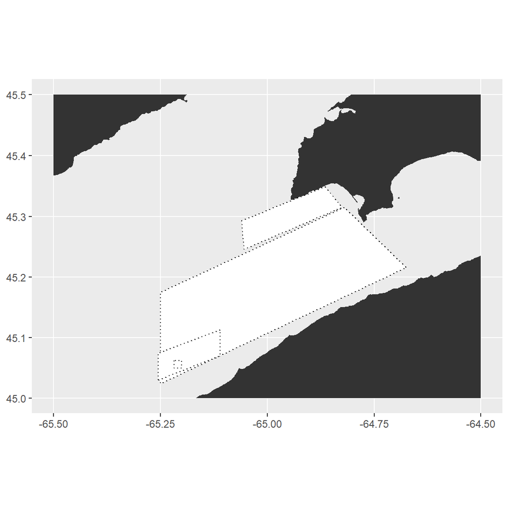

| Vessel | Tags |
| --- | --- |

### Plankton Data

#### Tow Depth Profiles

[figure not shown]

[figure not shown]

### CTD Data

[figure not shown]

#### Sea surface temperatures

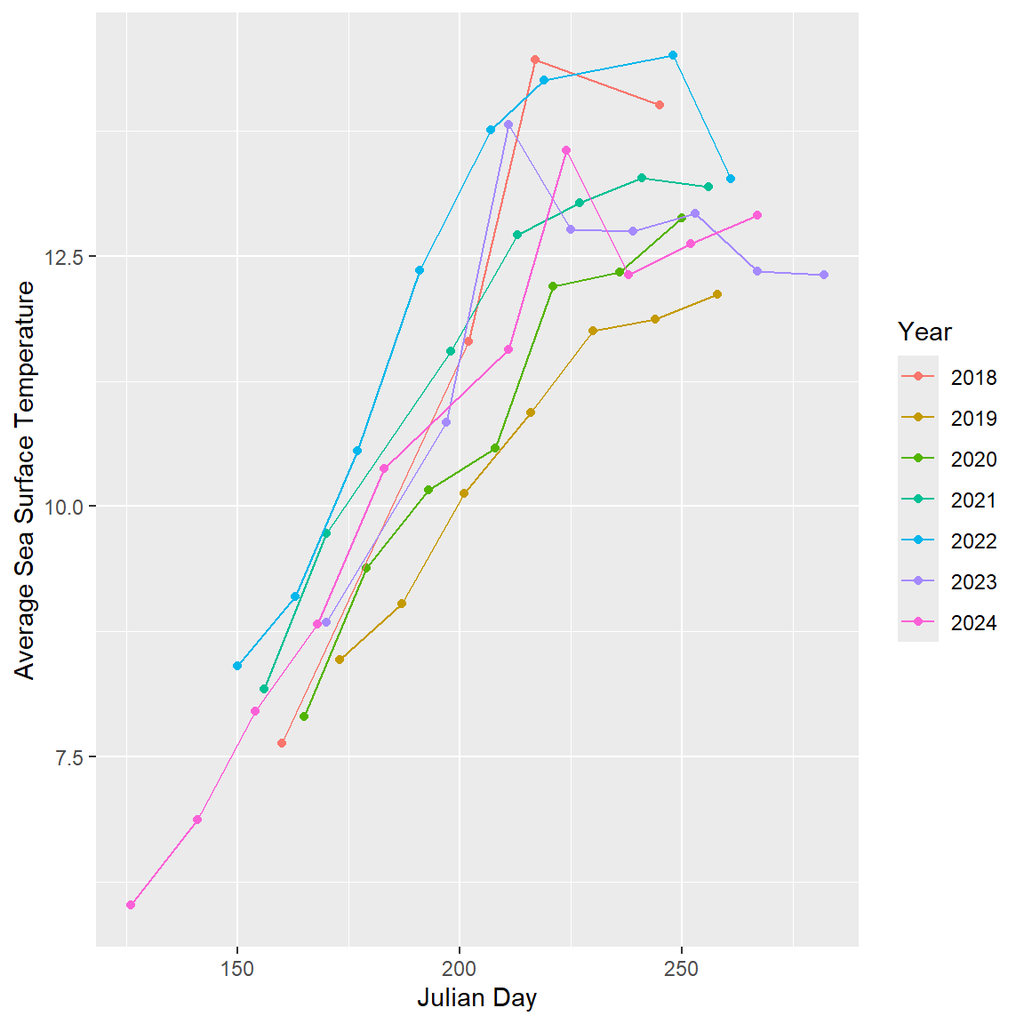

Annual average sea surface temperatures (SST) for Scots Bay.

## Vessel Performance

### Speed

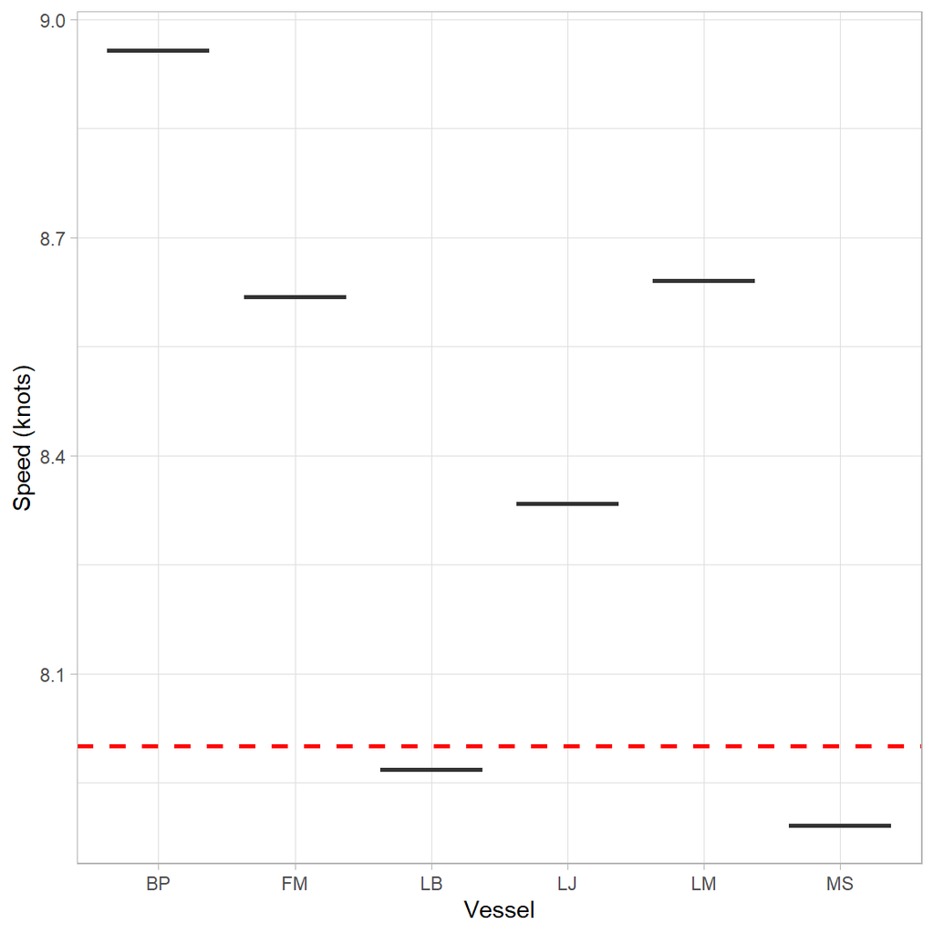

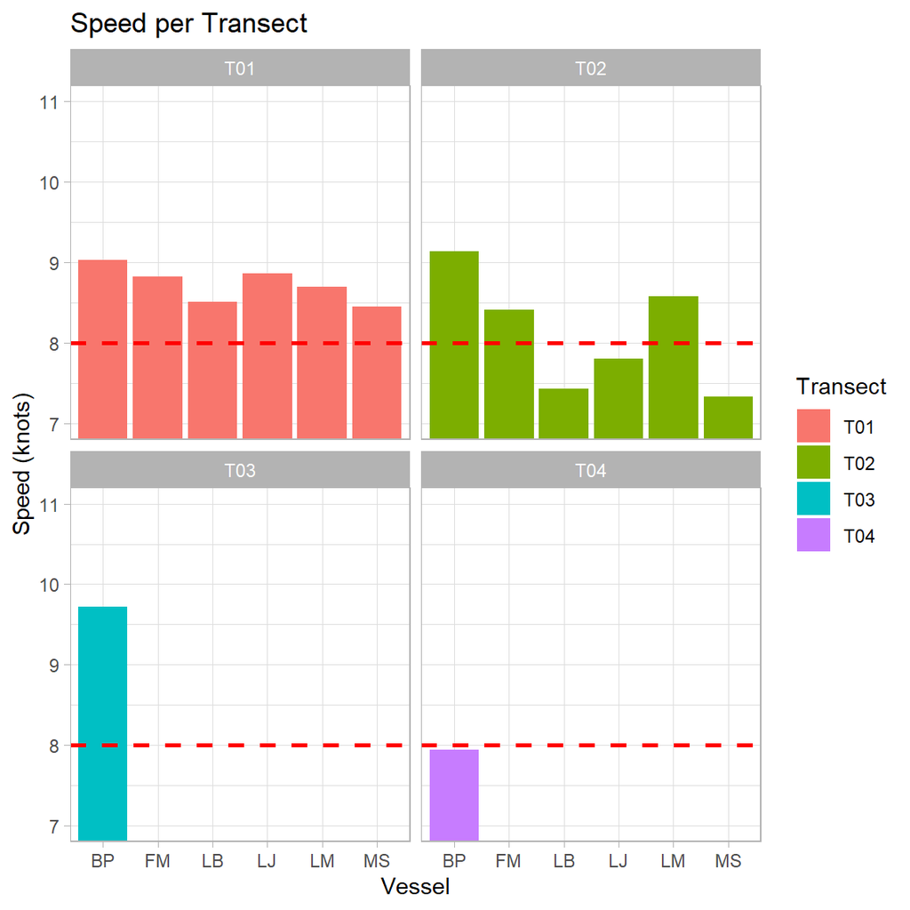

Average vessel speed was 8.4. This is above the 8 knot requirement; vessels are urged to slow down to prevent backscatter noise from interfering with the acoustic data.

The speed for each transect are rudimentary and are calculated based on distance. If a significant amount of distance is cut, the speed will appear slower.